# Regression with Single Regressor

# Linear Regression with One Regressor

This chapter introduces the basics in linear regression and shows how to perform regression analysis in `R`. In linear regression, the aim is to model the relationship between a dependent variable $Y$ and one or more explanatory variables denoted by $X_1, X_2, \dots, X_k$. Following the book we will focus on the concept of simple linear regression throughout the whole chapter. In simple linear regression, there is just one explanatory variable $X_1$.  
If, for example, a school cuts its class sizes by hiring new teachers, that is, the school lowers $X_1$, the student-teacher ratios of its classes, how would this affect $Y$, the performance of the students involved in a standardized test? With linear regression we can not only examine whether the student-teacher ratio *does have* an impact on the test results but we can also learn about the *direction* and the *strength* of this effect.

The following packages are needed for reproducing the code presented in this chapter:

- `AER` - accompanies the Book *Applied Econometrics with R* @kleiber2008 and provides useful functions and data sets.
- `MASS` - a collection of functions for applied statistics.

Make sure these are installed before you go ahead and try to replicate the examples. The safest way to do so is by checking whether the following code chunk executes without any errors.

```r
library(AER)
library(MASS)
```

## Simple Linear Regression

[output not shown]

To build simple linear regression model, we hypothesize that the relationship between dependent and independent variable is linear, formally:
$$Y = b \cdot X + a.$$
For now, let us suppose that the function which relates test score and student-teacher ratio to each other is
$$TestScore = 713 - 3 \times STR.$$

It is always a good idea to visualize the data you work with. Here, it is suitable to use `plot()` to produce a scatterplot with `STR` on the $x$-axis and `TestScore` on the $y$-axis. Just call `plot(y_variable ~ x_variable)` whereby `y_variable` and `y_variable` are placeholders for the vectors of observations we want to plot. Furthermore, we might want to add a systematic relationship to the plot. To draw a straight line, `R` provides the function `abline()`. We just have to call this function with arguments `a` (representing the intercept) and `b` (representing the slope) after executing `plot()` in order to add the line to our plot.

The following code reproduces Figure 4.1 from the textbook.

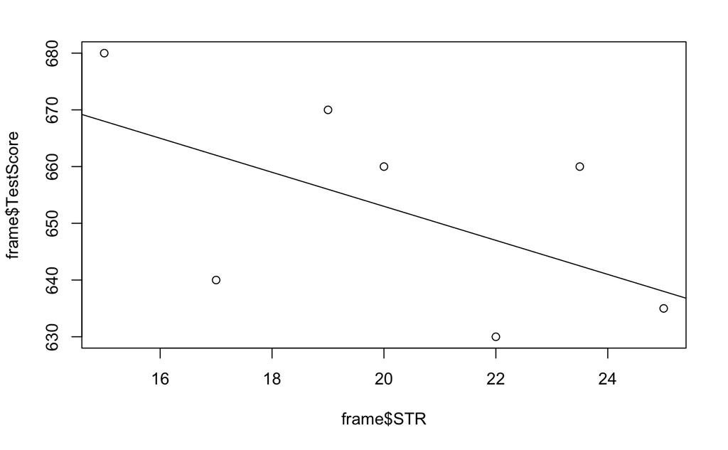

```r
# create a scatterplot of the data
plot(frame$TestScore ~ frame$STR)

# add the systematic relationship to the plot
abline(a = 713, b = -3)
```

## Estimating the Coefficients of the Linear Regression Model

In practice, the intercept $\beta_0$ and slope $\beta_1$ of the population regression line are unknown. Therefore, we must employ data to estimate both unknown parameters. In the following, a real world example will be used to demonstrate how this is achieved. We want to relate test scores to student-teacher ratios measured in Californian schools. The test score is the district-wide average of reading and math scores for fifth graders. Again, the class size is measured as the number of students divided by the number of teachers (the student-teacher ratio). * If the file type is `csv`, we download the data and use read `read.csv(file="path")` to load the data. * If the file type is `xlsx`, we use `read_excel()` in package `readxl`. * If the file type is `dta`, we use `read_stata()` in package `haven`.

```r
library(tidyverse)
library(haven)
# Import the data and look at the first six rows
# CASchools <- read_stata(file = '/Users/haoyu/Documents/GitHub/Slides_MECON/data/caschool.dta')

CASchools <- read_stata(file = 'http://fmwww.bc.edu/ec-p/data/stockwatson/caschool.dta')
head(CASchools)
```

| observation_number | dist_cod | county | district | gr_span | enrl_tot | teachers | calw_pct | meal_pct | computer | testscr | comp_stu | expn_stu | str | avginc | el_pct | read_scr | math_scr |
| --- | --- | --- | --- | --- | --- | --- | --- | --- | --- | --- | --- | --- | --- | --- | --- | --- | --- |
| 1 | 75119 | Alameda | Sunol Glen Unified | KK-08 | 195 | 10.90 | 0.5102 | 2.0408 | 67 | 690.80 | 0.3435898 | 6384.911 | 17.88991 | 22.690001 | 0.000000 | 691.6 | 690.0 |
| 2 | 61499 | Butte | Manzanita Elementary | KK-08 | 240 | 11.15 | 15.4167 | 47.9167 | 101 | 661.20 | 0.4208333 | 5099.381 | 21.52466 | 9.824000 | 4.583333 | 660.5 | 661.9 |
| 3 | 61549 | Butte | Thermalito Union Elementary | KK-08 | 1550 | 82.90 | 55.0323 | 76.3226 | 169 | 643.60 | 0.1090323 | 5501.955 | 18.69723 | 8.978000 | 30.000002 | 636.3 | 650.9 |
| 4 | 61457 | Butte | Golden Feather Union Elementary | KK-08 | 243 | 14.00 | 36.4754 | 77.0492 | 85 | 647.70 | 0.3497942 | 7101.831 | 17.35714 | 8.978000 | 0.000000 | 651.9 | 643.5 |
| 5 | 61523 | Butte | Palermo Union Elementary | KK-08 | 1335 | 71.50 | 33.1086 | 78.4270 | 171 | 640.85 | 0.1280899 | 5235.988 | 18.67133 | 9.080333 | 13.857677 | 641.8 | 639.9 |
| 6 | 62042 | Fresno | Burrel Union Elementary | KK-08 | 137 | 6.40 | 12.3188 | 86.9565 | 25 | 605.55 | 0.1824818 | 5580.147 | 21.40625 | 10.415000 | 12.408759 | 605.7 | 605.4 |

```r
# compute STR and append it to CASchools
CASchools$STR <- CASchools$enrl_tot/CASchools$teachers

# compute TestScore and append it to CASchools
CASchools$score <- (CASchools$read_scr + CASchools$math_scr)/2
```

If we ran `head(CASchools)` again we would find the two variables of interest as additional columns named `STR` and `score` (check this!).

The next code chunk shows how to achieve this. First, we compute summary statistics on the columns `STR` and `score` of `CASchools`. In order to get nice output we gather the measures in a `data.frame` named `"DistributionSummary`.

```r
# compute sample averages of STR and score
avg_STR <- mean(CASchools$STR)
avg_score <- mean(CASchools$score)

# compute sample standard deviations of STR and score
sd_STR <- sd(CASchools$STR)
sd_score <- sd(CASchools$score)

# set up a vector of percentiles and compute the quantiles
quantiles <- c(0.10, 0.25, 0.4, 0.5, 0.6, 0.75, 0.9)
quant_STR <- quantile(CASchools$STR, quantiles)
quant_score <- quantile(CASchools$score, quantiles)

# gather everything in a data.frame
DistributionSummary <- data.frame(Average = c(avg_STR, avg_score),
                                  StandardDeviation = c(sd_STR, sd_score),
                                  quantile = rbind(quant_STR, quant_score))

# print the summary to the console
DistributionSummary
```

|  | Average | StandardDeviation | quantile.10. | quantile.25. | quantile.40. | quantile.50. | quantile.60. | quantile.75. | quantile.90. |
| --- | --- | --- | --- | --- | --- | --- | --- | --- | --- |
| quant_STR | 19.64043 | 1.891812 | 17.3486 | 18.58236 | 19.26618 | 19.72321 | 20.0783 | 20.87181 | 21.86741 |
| quant_score | 654.15655 | 19.053347 | 630.3950 | 640.05000 | 649.06999 | 654.45000 | 659.4000 | 666.66249 | 678.85999 |

As for the sample data, we use `plot()`. This allows us to detect characteristics of our data, such as outliers which are harder to discover by looking at mere numbers. This time we add some additional arguments to the call of `plot()`.

The first argument in our call of `plot()`, `score ~ STR`, is again a formula that states variables on the y- and the x-axis. However, this time the two variables are not saved in separate vectors but are columns of `CASchools`. Therefore, `R` would not find them without the argument `data` being correctly specified. `data` must be in accordance with the name of the `data.frame` to which the variables belong to, in this case `CASchools`. Further arguments are used to change the appearance of the plot: while `main` adds a title, `xlab` and `ylab` add custom labels to both axes.

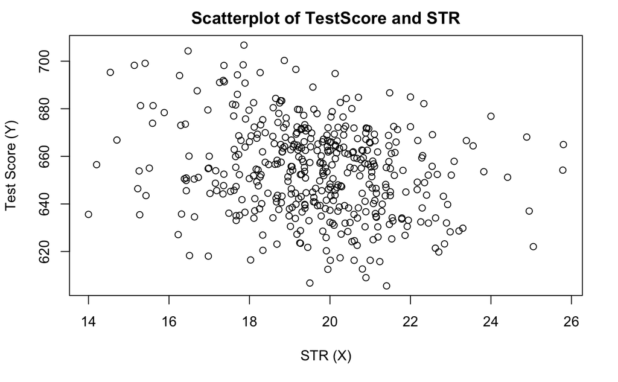

```r
plot(score ~ STR,
     data = CASchools,
     main = "Scatterplot of TestScore and STR",
     xlab = "STR (X)",
     ylab = "Test Score (Y)")
```

### The Ordinary Least Squares Estimator

The OLS estimator chooses the regression coefficients such that the estimated regression line is as “close” as possible to the observed data points. Here, closeness is measured by the sum of the squared mistakes made in predicting $Y$ given $X$. Let $b_0$ and $b_1$ be some estimators of $\beta_0$ and $\beta_1$. Then the sum of squared estimation mistakes can be expressed as

$$\sum^n_{i = 1} (Y_i - b_0 - b_1 X_i)^2.$$

There are many possible ways to compute $\hat{\beta}_0$ and $\hat{\beta}_1$ in `R`. For example, we could implement the formulas presented in Key Concept 4.2 with two of `R`’s most basic functions: `mean()` and `sum()`. Before doing so we *attach* the `CASchools` dataset.

[output not shown]

[output not shown]

Now we write the solution to the problem in matrix term. Recall that $X = \begin{bmatrix} 1 & STR_1 \\ \ldots & \ldots \\ 1 & STR_n \end{bmatrix}$ and $Y = \begin{bmatrix} y_1 \\ \vdots \\ y_n \end{bmatrix}$.

The estimator is solved to the system of linear equations
$$\hat \beta = (X^\top X)^{-1}(X^\top Y).$$
We use `cbind` to combine a vector of `1`’s with `STR`. Use `t()` to transpose a matrix and use `solve()` to perform matrix inversion. We can obtain the estimator of $\beta$.

```r
X = cbind(rep(1,length(STR)),STR)
Y = score
beta = solve(t(X) %*% X)   %*% ( t(X) %*% Y)
print(beta)
```

```
          [,1]
    698.932949
STR  -2.279808
```

Of course, there are even more manual ways to perform these tasks. With OLS being one of the most widely-used estimation techniques, `R` of course already contains a built-in function named `lm()` (**l**inear **m**odel) which can be used to carry out regression analysis.

The first argument of the function to be specified is, similar to `plot()`, the regression formula with the basic syntax `y ~ x` where `y` is the dependent variable and `x` the explanatory variable. The argument `data` determines the data set to be used in the regression. We now revisit the example from the book where the relationship between the test scores and the class sizes is analyzed. The following code uses `lm()` to replicate the results presented in figure 4.3 of the book.

```r
# estimate the model and assign the result to linear_model
linear_model <- lm(score ~ STR, data = CASchools)

# print the standard output of the estimated lm object to the console
linear_model
```

[output not shown]

## Measures of Fit

After fitting a linear regression model, a natural question is how well the model describes the data. Visually, this amounts to assessing whether the observations are tightly clustered around the regression line. Both the *coefficient of determination* and the *standard error of the regression* measure how well the OLS Regression line fits the data.

### The Coefficient of Determination

$R^2$, the *coefficient of determination*, is the fraction of the sample variance of $Y_i$ that is explained by $X_i$. Mathematically, the $R^2$ can be written as the ratio of the explained sum of squares to the total sum of squares. The *explained sum of squares* ($ESS$) is the sum of squared deviations of the predicted values $\hat{Y_i}$, from the average of the $Y_i$. The *total sum of squares* ($TSS$) is the sum of squared deviations of the $Y_i$ from their average. Thus we have

$$\begin{align}
ESS & = \sum_{i = 1}^n \left( \hat{Y_i} - \overline{Y} \right)^2, \\
TSS & = \sum_{i = 1}^n \left( Y_i - \overline{Y} \right)^2, \\
R^2 & = \frac{ESS}{TSS}.
\end{align}$$

Since $TSS = ESS + SSR$ we can also write

$$R^2 = 1- \frac{SSR}{TSS}$$

where $SSR$ is the sum of squared residuals, a measure for the errors made when predicting the $Y$ by $X$. The $SSR$ is defined as

$$SSR = \sum_{i=1}^n \hat{u}_i^2.$$

$R^2$ lies between $0$ and $1$. It is easy to see that a perfect fit, i.e., no errors made when fitting the regression line, implies $R^2 = 1$ since then we have $SSR=0$. On the contrary, if our estimated regression line does not explain any variation in the $Y_i$, we have $ESS=0$ and consequently $R^2=0$.

### The Standard Error of the Regression

The *Standard Error of the Regression* ($SER$) is an estimator of the standard deviation of the residuals $\hat{u}_i$. As such it measures the magnitude of a typical deviation from the regression line, i.e., the magnitude of a typical residual.

$$SER = s_{\hat{u}} = \sqrt{s_{\hat{u}}^2} \ \ \ \text{where} \ \ \ s_{\hat{u} }^2 = \frac{1}{n-2} \sum_{i = 1}^n \hat{u}^2_i = \frac{SSR}{n - 2}$$

Remember that the $u_i$ are *unobserved*. This is why we use their estimated counterparts, the residuals $\hat{u}_i$, instead. See Chapter 4.3 of the book for a more detailed comment on the $SER$.

### Application to the Test Score Data

Both measures of fit can be obtained by using the function `summary()` with an `lm` object provided as the only argument. While the function `lm()` only prints out the estimated coefficients to the console, `summary()` provides additional predefined information such as the regression’s $R^2$ and the $SER$.

```r
mod_summary <- summary(linear_model)
mod_summary
```

[output not shown]

Now, let us check whether `summar()` uses the same definitions for $R^2$ and $SER$ as we do when computing them manually.

```r
# compute R^2 manually
SSR <- sum(mod_summary$residuals^2)
TSS <- sum((score - mean(score))^2)
R2 <- 1 - SSR/TSS

# print the value to the console
R2

# compute SER manually
n <- nrow(CASchools)
SER <- sqrt(SSR / (n-2))

# print the value to the console
SER
```

[output not shown]